# Readme MEBSv1

# Summary of MEBS basic mode

Below we summarize the internal steps performed with MEBS in the basic mode using the main script mebsv1.pl

[figure not shown]

MEBS flowchart basic mode

# Modalities

The main modalities of MEBS are

1. **Score**: apturing the metabolic machinery of your genome or metagenome in terms of single scores
2. **Markers**: Detect possible marker genes according to their informational content (entropy)
3. **Completeness**: Evaluate the metabolic completeness of metabolic pathways
4. **Kegg visualization**: Visualizate the protein domains in your genome or metagenome using KEGG visualization

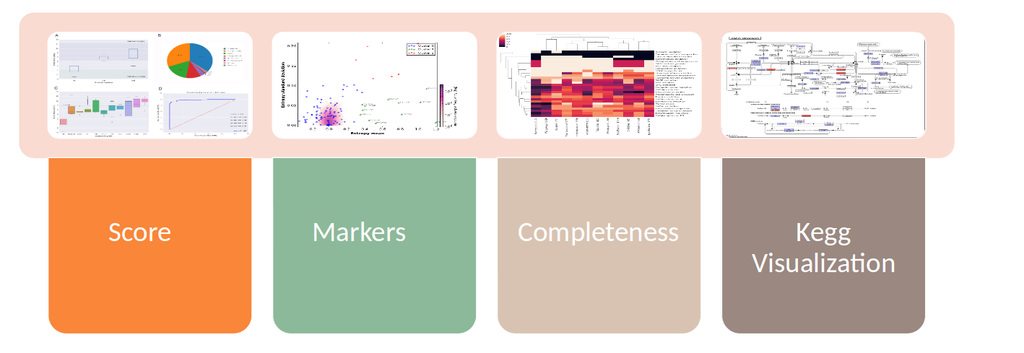

# External dependencies for advance mode

The following external packages are required if you want to benchmark your own metabolic pathway. Interproscan and hmmsearch are needed in order to annotate Pfam domains within peptide sequences. The rest of packages are needed to run the full pipeline, which comprises four steps.

1. Interproscan
2. [Python3](https://www.python.org/downloads)
3. [Matplotlib 1.4 or greater](http://matplotlib.org/users/installing.html#most-platforms-scientific-python-distributions)
4. [Numpy](https://docs.scipy.org/doc/numpy-1.10.0/user/install.html)
5. [Pandas](http://pandas.pydata.org/pandas-docs/stable/install.html)
6. [Scikit-learn](http://scikit-learn.org/stable/install.html)
7. Jupyter-notebook
8. [MPL_toolkits](http://matplotlib.org/1.4.3/mpl_toolkits/index.html)

# Scoring your data: Train your own classifier. Advanced Mode

For more advanced uses a manual is provided. The required input data are:

1. FASTA file with peptides sequences of proteins involved in the cycle/pathway of interest.
2. List of RefSeq accesions of (curated) genomes known to be involved in the cycle/pathway of interest.

These inputs are processed in order to train a classifier which internally uses [Pfam](http://pfam.xfam.org) domains.

As seen above, genomes or metagenomes provided by the user can then be scored with the trained classifier. Once a classifier has been trained, such as the Sulfur cycle, steps 1 and 3 can be skipped.

[figure not shown]

MEBS flowchart advance mode

# Support and Development

Planned feature improvements are publicly catalogued at the main MEBS development site on github. Bug reports and problems using MEBS are welcome on the issues tracker. We prefer posting to the issue tracker over email as these posts are searchable by other users who may experience the same problems.

# Cite

If you find this software usefull please cite us as:

- De Anda V, Zapata-Penasco I, Poot Hernandez AC, Fruns LE, Contreras Moreira B, Souza V (2017) MEBS, a software platform to evaluate large (meta)genomic collections according to their metabolic machinery: unraveling the sulfur cycle. [doi:10.1093/gigascience/gigascience/gix096/4561660](https://academic.oup.com/gigascience/advance-article/doi/10.1093/gigascience/gix096/4561660)